# Assessment 2

Veronika Varaksina s4646146

5/11/2021

## Assesment 2

Genshin Impact is a rpg game released and developed by MiHoYo Inc. in September 2020. It is a free to play game with in built payment options. By October 2021, Genshin Impact grossed over 2 billion dollars worldwide.The game received highly positive reviews and had 4.7 on Google play store. However, recent anniversary events were not well received by the game users. Google play store rating fell from 4.7 stars to 1.9 stars, which showcases public disappointment with the latest updates and anniversary events. In this research, twitter platform will be used to analyse users responses and potentially launch new marketing campaign to improve game ratings.

```r
final_data <- read.csv("final_genshin.csv")
data <- read.csv("final_genshin2.csv")
```

### Exploration and visualization of data

This step is based on a class workshop and uses `rtweet` package

1. Present the first 10 tweets from your dataset.

```r
final_data %>%
  head(10)
```

```
##         user_id    status_id           created_at    screen_name
## 1  2.864599e+09 1.454974e+18 2021-11-01T00:50:42Z DemonicBanshee
## 2  1.401992e+18 1.454974e+18 2021-11-01T00:50:39Z      keitaglia
## 3  1.401992e+18 1.454801e+18 2021-10-31T13:24:18Z      keitaglia
## 4  1.371852e+18 1.454974e+18 2021-11-01T00:50:36Z   Genshin_Nora
## 5  1.371852e+18 1.454973e+18 2021-11-01T00:44:43Z   Genshin_Nora
## 6  1.371852e+18 1.454972e+18 2021-11-01T00:42:58Z   Genshin_Nora
## 7  1.371852e+18 1.454972e+18 2021-11-01T00:41:43Z   Genshin_Nora
## 8  1.371852e+18 1.454974e+18 2021-11-01T00:50:05Z   Genshin_Nora
## 9  1.371852e+18 1.454943e+18 2021-10-31T22:47:33Z   Genshin_Nora
## 10 1.371852e+18 1.454972e+18 2021-11-01T00:41:26Z   Genshin_Nora
##                                                                                                                                                                                                                                text
## 1  And can't I have the gift box forever in my inventory? Like rhe cake in Genshin? It's so cute! Cat-themed, gold &amp; purple... It's perfect.\n\nAlso, Vyn is such a sweetheart to Rosa. It's endearing. https://t.co/aSO4aRC2QU
## 2                                                                                                                @HAIRPlN ITS EITHER HE CUT IT OR?? because when he talked abt the genshin and honkai thing he didnt share anything
## 3                                                                                                                                                      i'm finally opening genshin and .. im gonna cry /pos https://t.co/l0JQofvhcP
```

[output cut: 271 more lines]

2. Visualize the frequency of your tweets.

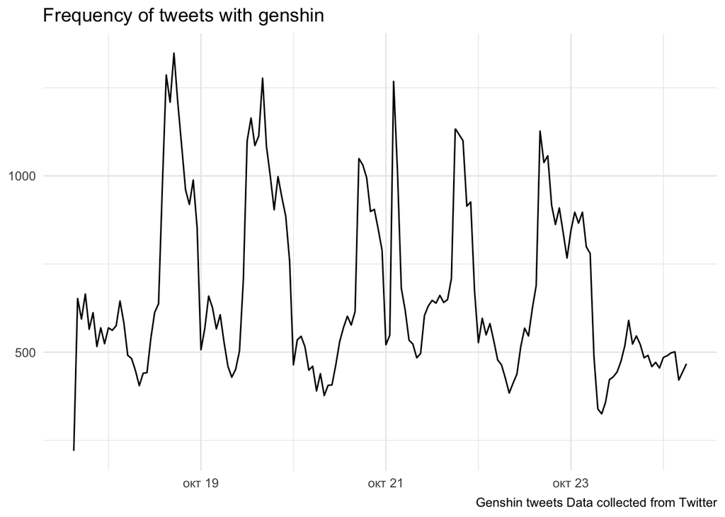

```r
data <- data %>%
  mutate(created_at = as_datetime(created_at))

ts_plot(data, "hours") +
  labs(x = NULL, y = NULL,
       title = "Frequency of tweets with genshin",
       caption = "Genshin tweets Data collected from Twitter") +
  theme_minimal()
```

3. Identify top tweeting locations and present the first 10.

```r
final_data %>%
  filter(!is.na(place_full_name)) %>%
  count(place_full_name, sort = TRUE) %>%
  head(10)
```

```
##               place_full_name n
## 1                    Honduras 7
## 2              Cuiabá, Brazil 4
## 3                      Kosovo 4
## 4            Teresina, Brazil 4
## 5  Cebu City, Central Visayas 3
## 6              Al Khor, Qatar 2
## 7         Damansara, Selangor 2
## 8    Davao City, Davao Region 2
## 9         George Town, Pinang 2
## 10                Hampton, VA 2
```

People rarely specify their locations on tweeter, hence the small number of places. But as we can see, the game is talked about worldwide, including number one Honduras, then Brazil, Kosovo and etc.

4. Identify the most retweeted tweets and present top 20.

```r
final_data %>%
  arrange(-retweet_count) %>%
  select(created_at, screen_name, text, retweet_count) %>%
  top_n(20)
```

```
##              created_at     screen_name
## 1  2021-10-19T18:19:53Z        ddengart
## 2  2021-10-22T23:11:05Z         pun_rii
## 3  2021-10-20T19:18:17Z        buruchii
## 4  2021-10-18T04:43:05Z Betina_Mascenon
## 5  2021-10-20T23:43:40Z      pablodp606
## 6  2021-10-22T23:11:05Z         pun_rii
## 7  2021-10-19T19:59:05Z   primeofadepti
## 8  2021-10-20T22:00:00Z       mizururu_
## 9  2021-10-19T18:19:53Z        ddengart
## 10 2021-10-26T04:02:17Z       AeEntropy
## 11 2021-10-31T19:51:29Z       bucumberr
## 12 2021-10-21T02:24:02Z   GenshinImpact
## 13 2021-10-20T01:04:37Z      lilyglazed
## 14 2021-10-18T23:33:46Z makeupagiplayer
```

[output cut: 48 more lines]

In 20 top retweeted tweets only 2 are from official Genshin Impact account, both of them share a link to mini games featuring game’s characters. However, majority of other top tweets have fanart in them, which means game users enjoy art and illustrations of their favorite characters. During the anniversary event, company could either make a illustration contest for in game rewards or release more wallpapers, illustration from company artists.

5. Identify the most liked tweets and present the first 15.

```r
final_data %>%
  arrange(-favorite_count) %>%
  top_n(15, favorite_count) %>%
  select(created_at, screen_name, text, favorite_count)
```

```
##              created_at     screen_name
## 1  2021-10-19T18:19:53Z        ddengart
## 2  2021-10-22T23:11:05Z         pun_rii
## 3  2021-10-20T19:18:17Z        buruchii
## 4  2021-10-20T23:43:40Z      pablodp606
## 5  2021-10-21T02:24:02Z   GenshinImpact
## 6  2021-10-26T05:41:17Z     yinniewater
## 7  2021-10-31T04:10:00Z   GenshinImpact
## 8  2021-10-18T04:43:05Z Betina_Mascenon
## 9  2021-10-19T18:36:09Z      Genshinmem
## 10 2021-10-19T19:59:05Z   primeofadepti
## 11 2021-10-26T04:02:17Z       AeEntropy
## 12 2021-10-20T22:00:00Z       mizururu_
## 13 2021-10-19T14:12:45Z        babufess
## 14 2021-10-18T23:33:46Z makeupagiplayer
```

[output cut: 33 more lines]

Most liked tweets cross over with most retweeted tweets. The most liked tweet states “Genshin fashion sketches. I’m thinking about turning these into acrylic standees”. Right now, MiHoYo does not release any 3D figurines or acrylic standees for purchase. So, tweets that have to do with creating those custom by the users receive a lot of likes from other game users, who are interesting in purchasing it too. Possibly, company could invest into creating official acrylic stands.

6. Identify top tweeters in your dataset and present the first 5. Write a sentence on your insights from this

```r
final_data %>%
  count(screen_name, sort = TRUE) %>%
  top_n(5) %>%
  mutate(screen_name = paste0("@", screen_name))
```

```
##      screen_name    n
## 1 @LITKO_Genshin 1083
## 2   @bot_genshin  640
## 3      @rudtuber  290
## 4 @JaemiCinnamon  190
## 5   @ren_diamond  174
```

7. Identify top emojis in your dataset and present the first 10.

```r
library(emo)
final_data %>%
  mutate(emoji = ji_extract_all(text)) %>%
  unnest(cols = c(emoji)) %>%
  count(emoji, sort = TRUE) %>%
  top_n(10)
```

```
## # A tibble: 10 × 2
##    emoji     n
##    <chr> <int>
##  1 😭    10986
##  2 🥺     1877
##  3 😂     1811
##  4 💀     1743
##  5 ✨     1539
##  6 😔     1437
##  7 ❤️      1089
##  8 🤣      968
##  9 👀      927
## 10 🥰      888
```

8. Identify top hashtags in your dataset and present the first 10.

```r
library(tidytext)
final_data %>%
  unnest_tokens(hashtag, text, "tweets", to_lower = FALSE) %>%
  filter(str_detect(hashtag, "^#"),
        hashtag != "#ClimateEmergency") %>%
  count(hashtag, sort = TRUE) %>%
  top_n(10)
```

```
##                 hashtag    n
## 1        #GenshinImpact 4787
## 2              #genshin 2667
## 3              #Genshin 1948
## 4           #genshintwt 1854
## 5        #genshinimpact 1736
## 6         #genshintrade  869
## 7        #GenshinImapct  782
## 8        #genshintrades  715
## 9  #genshinimpactfanart  672
## 10             #PS4live  651
```

9. Identify top mentions in your dataset and present the first 10.

```r
final_data %>%
  unnest_tokens(mentions, text, "tweets", to_lower = FALSE) %>%
  filter(str_detect(mentions, "^@")) %>%
  count(mentions, sort = TRUE) %>%
  top_n(10)
```

```
##            mentions    n
## 1    @GenshinImpact 1277
## 2     @LITKOGenshin  934
## 3     @GenshinIntel  887
## 4        @genshingi  825
## 5          @YouTube  805
## 6          @TectEGG  462
## 7    @GenshinKineli  460
## 8         @phaltron  443
## 9   @AsianGuyStream  375
## 10 @makeupagiplayer  320
```

As expected, official game account has the most amount of mentions, because this is a mention user use to show their frustration or suggest something. Second mention is an influencer account, it is the same one that was in top tweets.

```r
litko <- get_followers("LITKO_Genshin")
lookup_users(litko$user_id) %>%
  head(5)
```

```
## # A tibble: 5 × 90
##   user_id             status_id  created_at          screen_name  text    source
##   <chr>               <chr>      <dttm>              <chr>        <chr>   <chr>
## 1 1354220827063980032 146051767… 2021-11-16 07:58:43 Chloewasnot… @y4nfe… Twitt…
## 2 769576114448510978  145939911… 2021-11-13 05:53:58 artemis_ell… @seoki… Twitt…
## 3 1457892433296240640 145980449… 2021-11-14 08:44:49 clazeeaq     @juuzh… Twitt…
## 4 1458873317688057856 <NA>       NA                  brightern1g… <NA>    <NA>
## 5 1231824736511983617 146020446… 2021-11-15 11:14:07 albedoslver  @Rvnge… Twitt…
## # … with 84 more variables: display_text_width <int>, reply_to_status_id <chr>,
## #   reply_to_user_id <chr>, reply_to_screen_name <chr>, is_quote <lgl>,
## #   is_retweet <lgl>, favorite_count <int>, retweet_count <int>,
## #   quote_count <int>, reply_count <int>, hashtags <list>, symbols <list>,
## #   urls_url <list>, urls_t.co <list>, urls_expanded_url <list>,
## #   media_url <list>, media_t.co <list>, media_expanded_url <list>,
## #   media_type <list>, ext_media_url <list>, ext_media_t.co <list>, …
```

### Topic modeling and visualization

1. Preprocess text from your dataset to tidy text and convert it to DocumentTermMatrix

```r
tweet<-
  final_data%>%
  mutate(
    timestamp=ymd_hms(created_at),
    day_of_week=wday(timestamp),
    id=as_factor(row_number())
  )

remove_reg <- "&amp;|&lt;|&gt;|\\d+\\w*\\d*|#\\w+|[^\x01-\x7F]|[[:punct:]]|https\\S*"

tidy_tweets <- tweet %>%
  filter(!str_detect(text, "^RT")) %>%
  mutate(text = str_remove_all(text, remove_reg))

tidy_tweets<-tidy_tweets%>%
  unnest_tokens(word, text, token = "tweets")
```

```
## Using `to_lower = TRUE` with `token = 'tweets'` may not preserve URLs.
```

```r
tidy_tweets<-tidy_tweets%>%
  filter(
    str_detect(word, "[a-z]")
    )%>%
  anti_join((stop_words))
tidy_tweets <- tidy_tweets %>%
  filter(word != "genshin",
         word != "impact",
         word != "im")

bing<-get_sentiments("bing")
nrc<-get_sentiments("nrc")

selected_tweets_tidy<-tidy_tweets%>%select(timestamp, day_of_week, location, word, user_id)

selected_tweets_tidy<-selected_tweets_tidy%>%
  inner_join(bing)%>%
  rename(sentiment_bing=sentiment)%>%
inner_join(nrc)%>%
  rename(sentiment_nrc=sentiment)
tweets_dtm<-tidy_tweets%>%
  count(id, word)%>%
  cast_dtm(
    document=id,
    term=word,
    value=n,
    weighting=tm::weightTf
    )
tweets_dtm
```

```
## <<DocumentTermMatrix (documents: 179131, terms: 88056)>>
## Non-/sparse entries: 1143782/15772415554
## Sparsity           : 100%
## Maximal term length: 199
## Weighting          : term frequency (tf)
```

2. Use `LDA()` function to create an LDA model. Experiment with different number of topics (`k=`). Visualise the top 10 words from each topic to brainstorm on possible topics that they cover.

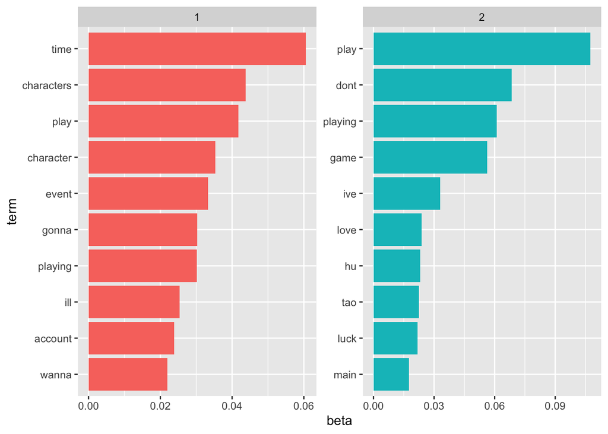

```r
tweets_dtm_trim<-tm::removeSparseTerms(tweets_dtm, sparse=.99)
rowTotals <- apply(tweets_dtm_trim, 1, sum)
tweets_dtm_trim <- tweets_dtm_trim[rowTotals> 0, ]

#LDA for 5 topics
tweets_lda<-LDA(tweets_dtm_trim, k=2, control=list(seed=1234))

tweet_topics<-tidy(tweets_lda, matrix="beta")

#let's look at them with 10 top words for each topic
tweet_top_terms <- tweet_topics %>%
  group_by(topic) %>%
  top_n(10, beta) %>%
  ungroup() %>%
  arrange(topic, -beta)

tweet_top_terms %>%
  filter(term != "genshin") %>%
  mutate(term = reorder_within(term, beta, topic)) %>%
  ggplot(aes(term, beta, fill = factor(topic))) +
  geom_col(show.legend = FALSE) +
  facet_wrap(~ topic, scales = "free") +
  coord_flip() +
  scale_x_reordered()
```